# TEMA 1 TEMA : Importar secuencias de otras plataformas de secuenciación

[figure not shown]

## 1.1 Importar secuencias de 454/Pyrosequencing

La pyrosecuenciación es una técnica de secuenciación del DNA que se basa en la detección de la liberación de pirofosfato durante la síntesis de DNA. Esta liberación ocurre cuando se agrega un nucleótido a una cadena en crecimiento. Al medir la cantidad de pirofosfato liberado, se determina la secuencia de DNA. Las secuencias se obtienen a partir de un pyrograma y se almacenan en un archivo denominado SFF (Standard Flowgram Format). A partir de este, se obtienen un archivo con las secuencias nucleotídicas en formato fasta y los datos de calidad en un formato llamado fasta.qual. Con estos archivos se puede generar el archivo fastq con el que estás más familiarizado.

Lo primero que haremos será descargar las secuencias a utilizar para este ejemplo:

```bash
wget --no-check-certificate 'https://docs.google.com/uc?export=download&id=13eDJLwVtxa3DeVD3pRIwJfYatX7IkPbu' -O pyro.zip
```

Los siguientes scripts son los que mencionamos en el video que se usan para obtener los archivos fastqc a partir de los archivos fasta y fasta.qual de pirosecuenciación en qiime1.

```bash
#primeros pasos en qiime1
conda activate qiime1

#separar por barcode y filtrar por calidad -d: record qual scores, -p: disable primers
# -b:barcode type 10, -s: min q score, -a: max ambioguos (bases), -e: max errors in barcodes
#-H: max homopolymer length
split_libraries.py\
-d -p -b 10\
-m MapfileARQ_corrected.txt\
-f ARQ_reads.fasta\
-q ARQ_reads.fasta.qual\
-s 0 -a 500 -e 2 -H 500\
-o split_ARQ

#A partir de un archivo FASTA y un archivo QUAL coincidente, genera un archivo FASTQ
convert_fastaqual_fastq.py\
-m -f split_ARQ/seqs.fna\
-q split_ARQ/seqs_filtered.qual\
-o split_ARQ_FQ
```

Script bash para generar el archivo manifest:

```bash
echo -e "sample-id\tabsolute-filepath" > manifest_pyros.txt | \
for file in $(ls *.fastq); do ruta=$(pwd) ; name=$(echo $file | \
sed 's/\.f.*//g') ; echo -e $name"\t"$ruta"/"$file ;\
done >> manifest_pyro.txt
```

Las secuencias de pyrosecuenciación se importan a `QIIME2` con el siguiente script:

```bash
qiime tools import\
 --type 'SampleData[SequencesWithQuality]'\
 --input-path manifest_pyro.txt\
 --output-path demux-pyro.qza\
 --input-format SingleEndFastqManifestPhred33V2
```

Para generar el visualizador del `demux` usamos el siguiente script:

```bash
qiime demux summarize\
 --i-data demux-pyro.qza\
 --o-visualization demux-pyro.qzv
```

[qiime2 view](https://view.qiime2.org/)

El primer paso después de importar es remover el primer si es necesario:

```bash
qiime cutadapt trim-single\
 --i-demultiplexed-sequences demux-pyro.qza\
 --p-cores 8\
 --p-front CYGGTTGATCCTGCCRG\
 --o-trimmed-sequences demux-pyro-trimmed.qza
```

Ahora vamos a generar el visualizador:

```bash
qiime demux summarize\
 --i-data demux-pyro-trimmed.qza\
 --o-visualization demux-pyro-trimmed.qzv
```

[qiime2 view](https://view.qiime2.org/)

**Spoiler alert!** Estas muestras contienen más de un marcador molecular. Esto lo podemos ver en el siguiente barplot y análisis blast de las secuencias unassigned.

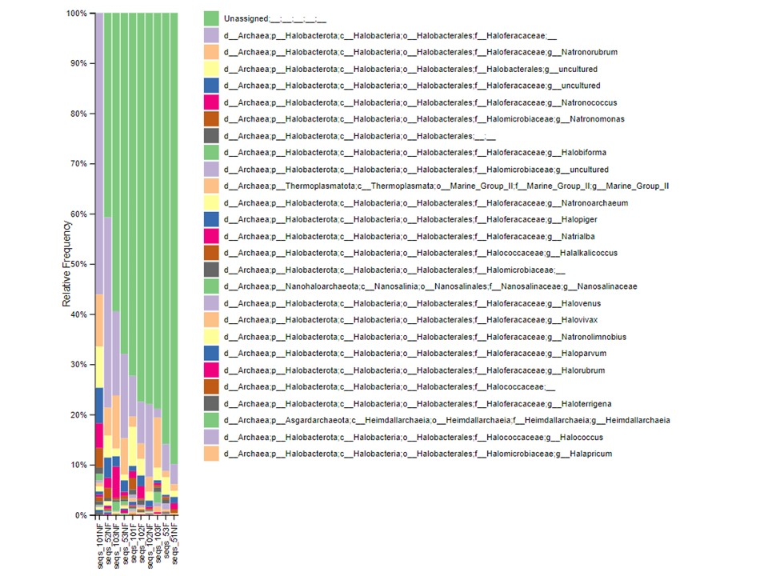

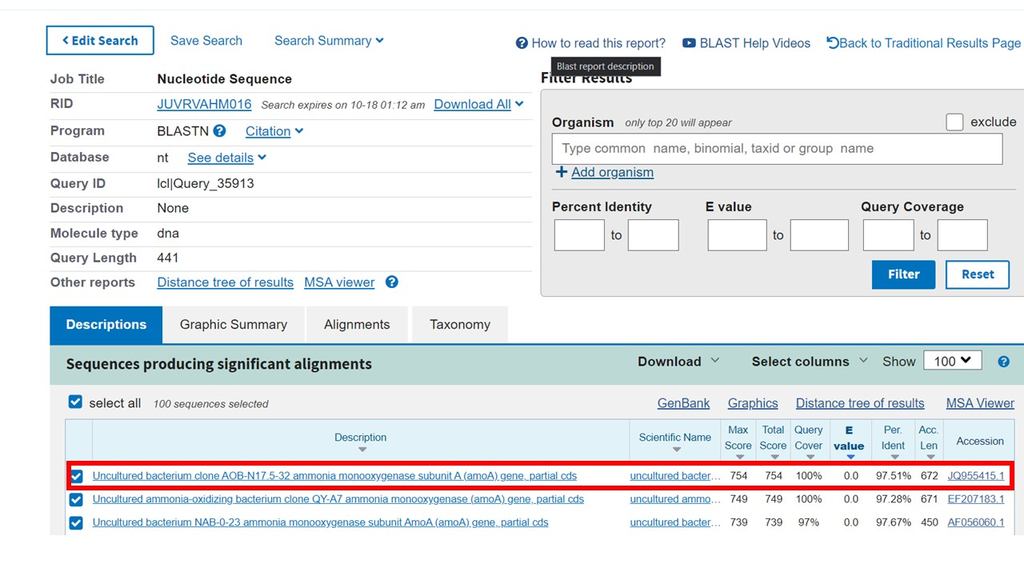

Ante esta situación… ¿Qué podemos hacer para remover estas secuencias no deseadas? Usar un método de filtrado para remover las secuencias del marcador molecular que no es de mi interés.

Obtención del index como referencia de la base de datos de silva con bowtie2:

```bash
qiime quality-control bowtie2-build\
 --i-sequences silva-138-99-seqs.qza\
 --p-n-threads 8\
 --o-database bowtie_silva
```

**Warning!** Para descargar las secuencias de la base de datos de SILVA usa el siguiente script:

```bash
wget https://data.qiime2.org/2024.5/common/silva-138-99-seqs.qza
```

Filtrado de secuencias por alineamiento con bowtie2:

```bash
qiime quality-control filter-reads\
 --i-demultiplexed-sequences demux-pyro-trimmed.qza\
 --i-database bowtie_silva.qza\
 --p-n-threads 8\
 --o-filtered-sequences demux-pyro-filtered.qza\
 --p-no-exclude-seqs
```

Visualizando el nuevo `demux` filtrado:

```bash
qiime demux summarize\
 --i-data demux-pyro-filtered.qza\
 --o-visualization demux-pyro-filtered.qzv
```

[qiime2 view](https://view.qiime2.org/)

### 1.1.1 Inferencia de ASVs para lecturas de 454/Pyrosequencing

Veamos los parámetros y opciones de la función:

```bash
qiime dada2 denoise-pyro  --help
```

Inferencia de ASVs:

```bash
qiime dada2 denoise-pyro\
 --i-demultiplexed-seqs demux-pyro-filtered.qza\
 --p-trunc-len 450\
 --output-dir dada2_pyro\
 --p-n-threads 8
```

Visualizando los estadísticos:

```bash
qiime metadata tabulate\
 --m-input-file denoising_stats.qza\
 --o-visualization denoising_stats.qzv
```

Una vez obtenida la tabla de frecuencias de features y las secuencias representativas (`FeatureTable[Frequency]` y `FeatureData[Sequence]`), pueden seguir un flujo de análisis normal de secuencias de 16S, es decir, hacer la asignación taxonómica y los análisis de diversidad alfa y beta como lo hemos hecho en otros temas o en otros cursos.

## 1.2 Importar secuencias de PacBio

La secuenciación PacBio se basa en la tecnología de secuenciación de una sola molécula en tiempo real (SMRT), que utiliza la observación directa de la incorporación de bases para leer el DNA. Esta técnica emplea polimerasas especiales que leen secuencias de DNA en tiempo real, generando lecturas más largas que otras tecnologías de secuenciación.

Los archivos de secuencias generados por PacBio están en formatos específicos, como el formato de archivo BAM (Binary Alignment/Map) que contiene datos alineados de secuencias de DNA, o en el formato fastq, el formato con el que estás familiarizado. Para nuestros ejercicios, importaremos secuencias de PacBio en formato fastq.

Primero, descargaremos la carpeta o directorio que contiene los archivos a utilizar en este ejercicio:

```bash
wget --no-check-certificate 'https://docs.google.com/uc?export=download&id=19CpwJjgCuCcpWFrxF9Y-LNcAzj4nfZz0' -O pacbio.zip
```

Script de bash para hacer el archivo manifest

```bash
echo -e "sample-id\tabsolute-filepath" > manifest_pacb.txt | \
for file in $(ls *.fastq); do ruta=$(pwd) ; name=$(echo $file | \
sed 's/\.f.*//g') ; echo -e $name"\t"$ruta"/"$file ;\
done >> manifest_pac.txt
```

Las secuencias de PacBio se importan a `QIIME2` con el siguiente script:

```bash
qiime tools import\
 --type 'SampleData[SequencesWithQuality]'\
 --input-path manifest_pac.txt\
 --output-path demux-pacbio.qza\
 --input-format SingleEndFastqManifestPhred33V2
```

Para generar el visualizador del `demux` usamos el siguiente script:

```bash
qiime demux summarize\
 --i-data demux-pacbio.qza\
 --o-visualization demux-pacbio.qzv
```

[qiime2 view](https://view.qiime2.org/)

### 1.2.1 Inferencia de ASVs para lecturas de PacBio

Veamos los parámetros y opciones de la función:

```bash
qiime dada2 denoise-ccs  --help
```

Inferencia de ASVs:

```bash
qiime dada2 denoise-ccs\
 --i-demultiplexed-seqs demux-pacbio.qza\
 --p-front AGRGTTYGATYMTGGCTCAG\
 --p-adapter RGYTACCTTGTTACGACTT\
 --p-min-len 1000\
 --p-max-len 1600\
 --output-dir dada2_pacbio
```

Visualizando los estadísticos:

```bash
qiime metadata tabulate\
 --m-input-file denoising_stats.qza\
 --o-visualization denoising_stats.qzv
```

Una vez obtenida la tabla de frecuencias de features y las secuencias representativas (`FeatureTable[Frequency]` y `FeatureData[Sequence]`), pueden seguir un flujo de análisis normal de secuencias de 16S, es decir, hacer la asignación taxonómica y los análisis de diversidad alfa y beta como lo hemos hecho en otros temas o en otros cursos.

## 1.3 Secuencias de Illumina (ejemplo de mala calidad)

En ocasiones, por diferentes razones, podemos tener secuencias paired-end de una corrida de mala calidad. Para no desperdiciar recursos, o si ya no tienes más DNA para repetir la secuenciación, puedes aplicar algunas estrategias para no perder tu información. En el siguiente ejercicio, te compartimos una estrategia.

Primero, vamos descargar el artefacto `demux` para el ejemplo:

```bash
https://drive.google.com/file/d/1zq7bDATeupokCProFWDmMaVajuW72srh/view?usp=drive_link
```

Y ahora inspeccionemos la calidad con el siguiente script:

```bash
qiime demux summarize\
 --i-data demux-subsample.qza\
 --o-visualization demux-subsample.qzv
```

[qiime2 view](https://view.qiime2.org/)

**Warning!** Las secuencias tienen mala calidad incluso para que se realice un merge (i.e. unión de las secuencias forward y reverse). **Aquí tenemos dos opciones:** 1) hacer el denoising con DADA2 single usando sólo las secuenciasforward ó 2) usar las secuencias paired-end a pesar de la calidad.

### 1.3.1 Opción 1: Denoising single.

Este es el código para hacer el denoising con DADA2 single usando sólo las forward:

```bash
qiime dada2 denoise-single\
 --i-demultiplexed-seqs demux-subsample.qza\
 --p-trunc-len 120\
 --output-dir single_120\
 --p-n-threads 0
```

Visualizando los estadísticos:

```bash
qiime metadata tabulate\
 --m-input-file denoising_stats.qza\
 --o-visualization denoising_stats.qzv
```

**Warning!** Es posible usar el artefacto de las secuencias paired-end (`PairedEndSequences`) para ejecutar el plugin `denoise-single`, en el que solo tomará las secuencias forward para hacer el denoise. No tengo que volver a importar solo las forward. Sin embargo, si tus secuencias reverse son de mejor calidad y las quieres trabajar con denoise-single, entonces sí debes importar nuevamente solo las reversas como si fueran secuencias single-end (`SingleEndSequences`).

### 1.3.2 Opción 2: Denoising paired.

Este es el código para usar las secuencias paired-end a pesar de la calidad:

```bash
qiime dada2 denoise-paired\
 --i-demultiplexed-seqs demux-subsample.qza\
 --p-trunc-len-f 260\
 --p-trunc-len-r 260\
 --output-dir paired_260
```

Visualizando los estadísticos:

```bash
qiime metadata tabulate\
 --m-input-file denoising_stats.qza\
 --o-visualization denoising_stats.qzv
```

Este ejercicio representa una estrategia para poder analizar secuencias de mala calidad. Puedes analizar el efecto de hacer un denoising single o paired-end puedes en la asignación taxonómica como ejercicio extracurso.